# 22067520 Dikshya Sharma

## Importing required libraries for data analysis and visualization

```python
# Importing the pandas library as pd for data manipulation and analysis
import pandas as pd

# Importing the matplotlib.pyplot module as plt for creating visualizations and plots
import matplotlib.pyplot as plt
```

## Program to Load the dataset from the provided CSV file for further analysis

```python
# Reading the CSV file 'CourseworkDataset.csv' and storing the data in a DataFrame variable named 'data'
dataSets=pd.read_csv('CourseworkDataset.csv')
```

### Displaying loaded datasets from CSV file

```python
# Displaying a sample of the loaded dataset to verify its contents
print("\nSample of the DataScienceSalaries csv file:")
print("\n================================================================================\n")

print(dataSets.sample(10))  # Displaying a random sample of ten rows from the DataFrame
```

```
Sample of the DataScienceSalaries csv file:

================================================================================

      work_year experience_level employment_type           job_title  salary  \
694        2023               EN              FT       Data Engineer   73900
2674       2022               SE              FT   Applied Scientist  191475
152        2023               SE              FT  Analytics Engineer  143200
1795       2023               SE              FT       Data Engineer  180000
12         2023               SE              FT        Data Analyst  100000
2443       2022               SE              FT      Data Scientist  104000
3598       2021               EN              FT      Data Scientist   31000
2233       2022               SE              FT      Data Architect  175000
2552       2022               SE              FT        Data Analyst   95000
705        2023               MI              FT       Data Engineer   70000
```

[output cut: 24 more lines]

# Data Preparation

### Write a python program to load data into pandas DataFrame

```python
#loading the data into a pandas DataFrame
df = pd.DataFrame(dataSets)
```

```python
# Printing the original DataFrame for visualization
print("\n=============================Original DataFrame =============================\n")
print(df)
print("\n========================================================================\n")
```

```
=============================Original DataFrame =============================

      work_year experience_level employment_type                 job_title  \
0          2023               SE              FT  Principal Data Scientist
1          2023               MI              CT               ML Engineer
2          2023               MI              CT               ML Engineer
3          2023               SE              FT            Data Scientist
4          2023               SE              FT            Data Scientist
...         ...              ...             ...                       ...
3750       2020               SE              FT            Data Scientist
3751       2021               MI              FT  Principal Data Scientist
3752       2020               EN              FT            Data Scientist
3753       2020               EN              CT     Business Data Analyst
3754       2021               SE              FT      Data Science Manager

```

[output cut: 29 more lines]

## Write a python program to remove unnecessary columns i.e., salary and salary currency.

```python
# Removing the 'salary' column from the DataFrame 'df'
df.drop('salary', axis=1, inplace=True)

# Removing the 'salary_currency' column from the DataFrame 'df'
df.drop('salary_currency', axis=1, inplace=True)
```

```python
# Displaying the DataFrame after removing unnecessary columns
print("\n------------------------------ Modified DataFrame -----------------------------\n")
print(df)
print("\n-------------------------------------------------------------------------------\n")
```

```
------------------------------ Modified DataFrame -----------------------------

      work_year experience_level employment_type                 job_title  \
0          2023               SE              FT  Principal Data Scientist
1          2023               MI              CT               ML Engineer
2          2023               MI              CT               ML Engineer
3          2023               SE              FT            Data Scientist
4          2023               SE              FT            Data Scientist
...         ...              ...             ...                       ...
3750       2020               SE              FT            Data Scientist
3751       2021               MI              FT  Principal Data Scientist
3752       2020               EN              FT            Data Scientist
3753       2020               EN              CT     Business Data Analyst
3754       2021               SE              FT      Data Science Manager

```

[output cut: 29 more lines]

## Write a python program to remove the NaN missing values from updated dataframe.

```python
# Providing a comprehensive view of all columns within the DataFrame for better understanding
print("Columns of the DataFrame:")
print("-"* 80)
print(df.columns)
```

```
Columns of the DataFrame:
--------------------------------------------------------------------------------
Index(['work_year', 'experience_level', 'employment_type', 'job_title',
       'salary_in_usd', 'employee_residence', 'remote_ratio',
       'company_location', 'company_size'],
      dtype='object')
```

```python
# Checking for missing values in each column of the DataFrame
missing_values=df.isnull().any()

# Displaying the presence of NaN missing values within the DataFrame, if any
print("\nPresence of NaN Missing Values within the DataFrame:\n", "-" *60)
missing_values
```

```
Presence of NaN Missing Values within the DataFrame:
 ------------------------------------------------------------
```

```
work_year             False
experience_level      False
employment_type       False
job_title             False
salary_in_usd         False
employee_residence    False
remote_ratio          False
company_location      False
company_size          False
dtype: bool
```

```python
# Calculating the column-wise sum of NaN (missing) values
missing_value_count = df.isnull().sum()

# Displaying the count of NaN Missing Values within the DataFrame, if any
print("\nCount of NaN Missing Values within the DataFrame:\n", "-" * 50)
missing_value_count
```

```
Count of NaN Missing Values within the DataFrame:
 --------------------------------------------------
```

```
work_year             0
experience_level      0
employment_type       0
job_title             0
salary_in_usd         0
employee_residence    0
remote_ratio          0
company_location      0
company_size          0
dtype: int64
```

```python
# Checking for rows with NaN (missing) values and displaying them if present
rows_with_missing_values = df[df.isnull().any(axis=1)]

# If there are no missing values, display a message
if rows_with_missing_values.empty:
    print("\nNo NaN Missing Values present within the DataFrame.")
else:
    print("\nRows with NaN Missing Values within the DataFrame:")
    print(rows_with_missing_values)
```

```
No NaN Missing Values present within the DataFrame.
```

```python
# Removing NaN missing values from the DataFrame
missing_values_removed = df.dropna(inplace=True)

# If there are no missing values removed, print a message
if missing_values_removed is None:
    print("\nNo NaN missing values found in the DataFrame. No rows were removed.")
else:
    print("\nMissing Values Removed:", missing_values_removed)
```

```
No NaN missing values found in the DataFrame. No rows were removed.
```

## Write a python program to check duplicates value in the dataframe.

```python
# Checking for the existence of any duplicate values in the DataFrame
duplicate_values = df.duplicated()

# Displaying the result of duplicate value check
print("\nDuplicate Values Existence in the DataFrame:", duplicate_values.any())
```

```
Duplicate Values Existence in the DataFrame: True
```

```python
# Counting the number of duplicate rows in the DataFrame
duplicated_rows_count = duplicate_values.sum()

# Displaying the number of duplicated rows
print("Number of duplicated rows:", duplicated_rows_count)
```

```
Number of duplicated rows: 1171
```

```python
# Selecting rows in DataFrame 'df' that are duplicates based on all columns and creating a new DataFrame 'Duplicates'
duplicates_entries = df[duplicate_values]

# Displaying the DataFrame consisting of duplicate values only
print("\nDataFrame with Duplicated Values:")
print("-"* 80)
print(duplicates_entries)
```

```
DataFrame with Duplicated Values:
--------------------------------------------------------------------------------
      work_year experience_level employment_type           job_title  \
115        2023               SE              FT      Data Scientist
123        2023               SE              FT  Analytics Engineer
153        2023               MI              FT       Data Engineer
154        2023               MI              FT       Data Engineer
160        2023               SE              FT       Data Engineer
...         ...              ...             ...                 ...
3439       2022               MI              FT      Data Scientist
3440       2022               SE              FT       Data Engineer
3441       2022               SE              FT       Data Engineer
3586       2021               MI              FT       Data Engineer
3709       2021               MI              FT      Data Scientist

```

[output cut: 27 more lines]

```python
# Dropping duplicate rows from the DataFrame 'df'
df.drop_duplicates(inplace=True)

# Displaying the updated DataFrame after removing duplicates
print("\nThe DataFrame after removing duplicate values:")
df.drop_duplicates(inplace=True)
df
```

```
The DataFrame after removing duplicate values:
```

|  | work_year | experience_level | employment_type | job_title | salary_in_usd | employee_residence | remote_ratio | company_location | company_size |
| --- | --- | --- | --- | --- | --- | --- | --- | --- | --- |
| 0 | 2023 | SE | FT | Principal Data Scientist | 85847 | ES | 100 | ES | L |
| 1 | 2023 | MI | CT | ML Engineer | 30000 | US | 100 | US | S |
| 2 | 2023 | MI | CT | ML Engineer | 25500 | US | 100 | US | S |
| 3 | 2023 | SE | FT | Data Scientist | 175000 | CA | 100 | CA | M |
| 4 | 2023 | SE | FT | Data Scientist | 120000 | CA | 100 | CA | M |
| ... | ... | ... | ... | ... | ... | ... | ... | ... | ... |
| 3750 | 2020 | SE | FT | Data Scientist | 412000 | US | 100 | US | L |
| 3751 | 2021 | MI | FT | Principal Data Scientist | 151000 | US | 100 | US | L |
| 3752 | 2020 | EN | FT | Data Scientist | 105000 | US | 100 | US | S |
| 3753 | 2020 | EN | CT | Business Data Analyst | 100000 | US | 100 | US | L |
| 3754 | 2021 | SE | FT | Data Science Manager | 94665 | IN | 50 | IN | L |

2584 rows × 9 columns

## Write a python program to see the unique values from all the columns in the dataframe.

```python
# Printing the list of column names in the DataFrame
print("Column Names:")
print(df.columns)
```

```
Column Names:
Index(['work_year', 'experience_level', 'employment_type', 'job_title',
       'salary_in_usd', 'employee_residence', 'remote_ratio',
       'company_location', 'company_size'],
      dtype='object')
```

```python
# Iterate over each column in the DataFrame and print its unique values
for column in df.columns:
    unique_values = df[column].unique()
    print(f"Unique values in column '{column}': {unique_values}")
```

```
Unique values in column 'work_year': [2023 2022 2020 2021]
Unique values in column 'experience_level': ['SE' 'MI' 'EN' 'EX']
Unique values in column 'employment_type': ['FT' 'CT' 'FL' 'PT']
Unique values in column 'job_title': ['Principal Data Scientist' 'ML Engineer' 'Data Scientist'
 'Applied Scientist' 'Data Analyst' 'Data Modeler' 'Research Engineer'
 'Analytics Engineer' 'Business Intelligence Engineer'
 'Machine Learning Engineer' 'Data Strategist' 'Data Engineer'
 'Computer Vision Engineer' 'Data Quality Analyst'
 'Compliance Data Analyst' 'Data Architect'
 'Applied Machine Learning Engineer' 'AI Developer' 'Research Scientist'
 'Data Analytics Manager' 'Business Data Analyst' 'Applied Data Scientist'
 'Staff Data Analyst' 'ETL Engineer' 'Data DevOps Engineer' 'Head of Data'
 'Data Science Manager' 'Data Manager' 'Machine Learning Researcher'
 'Big Data Engineer' 'Data Specialist' 'Lead Data Analyst'
 'BI Data Engineer' 'Director of Data Science'
 'Machine Learning Scientist' 'MLOps Engineer' 'AI Scientist'
 'Autonomous Vehicle Technician' 'Applied Machine Learning Scientist'
 'Lead Data Scientist' 'Cloud Database Engineer' 'Financial Data Analyst'
 'Data Infrastructure Engineer' 'Software Data Engineer' 'AI Programmer'
 'Data Operations Engineer' 'BI Developer' 'Data Science Lead'
 'Deep Learning Researcher' 'BI Analyst' 'Data Science Consultant'
 'Data Analytics Specialist' 'Machine Learning Infrastructure Engineer'
 'BI Data Analyst' 'Head of Data Science' 'Insight Analyst'
 'Deep Learning Engineer' 'Machine Learning Software Engineer'
 'Big Data Architect' 'Product Data Analyst'
 'Computer Vision Software Engineer' 'Azure Data Engineer'
 'Marketing Data Engineer' 'Data Analytics Lead' 'Data Lead'
 'Data Science Engineer' 'Machine Learning Research Engineer'
 'NLP Engineer' 'Manager Data Management' 'Machine Learning Developer'
 '3D Computer Vision Researcher' 'Principal Machine Learning Engineer'
 'Data Analytics Engineer' 'Data Analytics Consultant'
 'Data Management Specialist' 'Data Science Tech Lead'
 'Data Scientist Lead' 'Cloud Data Engineer' 'Data Operations Analyst'
 'Marketing Data Analyst' 'Power BI Developer' 'Product Data Scientist'
 'Principal Data Architect' 'Machine Learning Manager'
 'Lead Machine Learning Engineer' 'ETL Developer' 'Cloud Data Architect'
 'Lead Data Engineer' 'Head of Machine Learning' 'Principal Data Analyst'
 'Principal Data Engineer' 'Staff Data Scientist' 'Finance Data Analyst']
Unique values in column 'salary_in_usd': [ 85847  30000  25500 ...  28369 412000  94665]
Unique values in column 'employee_residence': ['ES' 'US' 'CA' 'DE' 'GB' 'NG' 'IN' 'HK' 'PT' 'NL' 'CH' 'CF' 'FR' 'AU'
 'FI' 'UA' 'IE' 'IL' 'GH' 'AT' 'CO' 'SG' 'SE' 'SI' 'MX' 'UZ' 'BR' 'TH'
 'HR' 'PL' 'KW' 'VN' 'CY' 'AR' 'AM' 'BA' 'KE' 'GR' 'MK' 'LV' 'RO' 'PK'
 'IT' 'MA' 'LT' 'BE' 'AS' 'IR' 'HU' 'SK' 'CN' 'CZ' 'CR' 'TR' 'CL' 'PR'
 'DK' 'BO' 'PH' 'DO' 'EG' 'ID' 'AE' 'MY' 'JP' 'EE' 'HN' 'TN' 'RU' 'DZ'
 'IQ' 'BG' 'JE' 'RS' 'NZ' 'MD' 'LU' 'MT']
Unique values in column 'remote_ratio': [100   0  50]
Unique values in column 'company_location': ['ES' 'US' 'CA' 'DE' 'GB' 'NG' 'IN' 'HK' 'NL' 'CH' 'CF' 'FR' 'FI' 'UA'
 'IE' 'IL' 'GH' 'CO' 'SG' 'AU' 'SE' 'SI' 'MX' 'BR' 'PT' 'RU' 'TH' 'HR'
 'VN' 'EE' 'AM' 'BA' 'KE' 'GR' 'MK' 'LV' 'RO' 'PK' 'IT' 'MA' 'PL' 'AL'
 'AR' 'LT' 'AS' 'CR' 'IR' 'BS' 'HU' 'AT' 'SK' 'CZ' 'TR' 'PR' 'DK' 'BO'
 'PH' 'BE' 'ID' 'EG' 'AE' 'LU' 'MY' 'HN' 'JP' 'DZ' 'IQ' 'CN' 'NZ' 'CL'
 'MD' 'MT']
Unique values in column 'company_size': ['L' 'S' 'M']
```

## Rename the experience level columns as below.

SE – Senior Level/Expert MI – Medium Level/Intermediate EN – Entry Level EX – Executive Level

### Define a dictionary to rename 'SE' to 'Senior Level/Expert'

```python
# Defining a dictionary to rename 'SE' (Software Engineer) to 'Senior Level/Expert'
title_rename_mapping = {'SE': "Senior Level/Expert"}

# Replacing job titles in the DataFrame 'df' using the renaming dictionary
df.replace(title_rename_mapping, inplace=True)
```

```python
df
```

|  | work_year | experience_level | employment_type | job_title | salary_in_usd | employee_residence | remote_ratio | company_location | company_size |
| --- | --- | --- | --- | --- | --- | --- | --- | --- | --- |
| 0 | 2023 | Senior Level/Expert | FT | Principal Data Scientist | 85847 | ES | 100 | ES | L |
| 1 | 2023 | MI | CT | ML Engineer | 30000 | US | 100 | US | S |
| 2 | 2023 | MI | CT | ML Engineer | 25500 | US | 100 | US | S |
| 3 | 2023 | Senior Level/Expert | FT | Data Scientist | 175000 | CA | 100 | CA | M |
| 4 | 2023 | Senior Level/Expert | FT | Data Scientist | 120000 | CA | 100 | CA | M |
| ... | ... | ... | ... | ... | ... | ... | ... | ... | ... |
| 3750 | 2020 | Senior Level/Expert | FT | Data Scientist | 412000 | US | 100 | US | L |
| 3751 | 2021 | MI | FT | Principal Data Scientist | 151000 | US | 100 | US | L |
| 3752 | 2020 | EN | FT | Data Scientist | 105000 | US | 100 | US | S |
| 3753 | 2020 | EN | CT | Business Data Analyst | 100000 | US | 100 | US | L |
| 3754 | 2021 | Senior Level/Expert | FT | Data Science Manager | 94665 | IN | 50 | IN | L |

2584 rows × 9 columns

### Define a dictionary to rename 'MI' to 'Medium Level/Intermediate'

```python
# Defining a dictionary to rename  'MI' to 'Medium Level/Intermediate'
title_rename_mapping =  {'MI': "Medium Level/Intermediate"}

# Replacing job titles in the DataFrame 'df' using the renaming dictionary
df.replace(title_rename_mapping, inplace=True)
```

```python
df
```

|  | work_year | experience_level | employment_type | job_title | salary_in_usd | employee_residence | remote_ratio | company_location | company_size |
| --- | --- | --- | --- | --- | --- | --- | --- | --- | --- |
| 0 | 2023 | Senior Level/Expert | FT | Principal Data Scientist | 85847 | ES | 100 | ES | L |
| 1 | 2023 | Medium Level/Intermediate | CT | ML Engineer | 30000 | US | 100 | US | S |
| 2 | 2023 | Medium Level/Intermediate | CT | ML Engineer | 25500 | US | 100 | US | S |
| 3 | 2023 | Senior Level/Expert | FT | Data Scientist | 175000 | CA | 100 | CA | M |
| 4 | 2023 | Senior Level/Expert | FT | Data Scientist | 120000 | CA | 100 | CA | M |
| ... | ... | ... | ... | ... | ... | ... | ... | ... | ... |
| 3750 | 2020 | Senior Level/Expert | FT | Data Scientist | 412000 | US | 100 | US | L |
| 3751 | 2021 | Medium Level/Intermediate | FT | Principal Data Scientist | 151000 | US | 100 | US | L |
| 3752 | 2020 | EN | FT | Data Scientist | 105000 | US | 100 | US | S |
| 3753 | 2020 | EN | CT | Business Data Analyst | 100000 | US | 100 | US | L |
| 3754 | 2021 | Senior Level/Expert | FT | Data Science Manager | 94665 | IN | 50 | IN | L |

2584 rows × 9 columns

### Define a dictionary to rename 'EN' to 'Entry Level'

```python
# Defining a dictionary to rename 'EN' (Entry Level) to 'Entry Level'
title_update_mapping = {'EN': "Entry Level"}

# Replacing job titles in the DataFrame 'df' using the renaming dictionary
df.replace(title_update_mapping, inplace=True)
```

```python
df
```

|  | work_year | experience_level | employment_type | job_title | salary_in_usd | employee_residence | remote_ratio | company_location | company_size |
| --- | --- | --- | --- | --- | --- | --- | --- | --- | --- |
| 0 | 2023 | Senior Level/Expert | FT | Principal Data Scientist | 85847 | ES | 100 | ES | L |
| 1 | 2023 | Medium Level/Intermediate | CT | ML Engineer | 30000 | US | 100 | US | S |
| 2 | 2023 | Medium Level/Intermediate | CT | ML Engineer | 25500 | US | 100 | US | S |
| 3 | 2023 | Senior Level/Expert | FT | Data Scientist | 175000 | CA | 100 | CA | M |
| 4 | 2023 | Senior Level/Expert | FT | Data Scientist | 120000 | CA | 100 | CA | M |
| ... | ... | ... | ... | ... | ... | ... | ... | ... | ... |
| 3750 | 2020 | Senior Level/Expert | FT | Data Scientist | 412000 | US | 100 | US | L |
| 3751 | 2021 | Medium Level/Intermediate | FT | Principal Data Scientist | 151000 | US | 100 | US | L |
| 3752 | 2020 | Entry Level | FT | Data Scientist | 105000 | US | 100 | US | S |
| 3753 | 2020 | Entry Level | CT | Business Data Analyst | 100000 | US | 100 | US | L |
| 3754 | 2021 | Senior Level/Expert | FT | Data Science Manager | 94665 | IN | 50 | IN | L |

2584 rows × 9 columns

### Define a dictionary to rename 'EX' to 'Executive Level'

```python
# Defining a dictionary to rename 'EX' to 'Executive Level'
title_update_mapping = {'EX': "Executive Level"}

# Replacing job titles in the DataFrame 'df' using the renaming dictionary
df.replace(title_update_mapping, inplace=True)
```

```python
df
```

|  | work_year | experience_level | employment_type | job_title | salary_in_usd | employee_residence | remote_ratio | company_location | company_size |
| --- | --- | --- | --- | --- | --- | --- | --- | --- | --- |
| 0 | 2023 | Senior Level/Expert | FT | Principal Data Scientist | 85847 | ES | 100 | ES | L |
| 1 | 2023 | Medium Level/Intermediate | CT | ML Engineer | 30000 | US | 100 | US | S |
| 2 | 2023 | Medium Level/Intermediate | CT | ML Engineer | 25500 | US | 100 | US | S |
| 3 | 2023 | Senior Level/Expert | FT | Data Scientist | 175000 | CA | 100 | CA | M |
| 4 | 2023 | Senior Level/Expert | FT | Data Scientist | 120000 | CA | 100 | CA | M |
| ... | ... | ... | ... | ... | ... | ... | ... | ... | ... |
| 3750 | 2020 | Senior Level/Expert | FT | Data Scientist | 412000 | US | 100 | US | L |
| 3751 | 2021 | Medium Level/Intermediate | FT | Principal Data Scientist | 151000 | US | 100 | US | L |
| 3752 | 2020 | Entry Level | FT | Data Scientist | 105000 | US | 100 | US | S |
| 3753 | 2020 | Entry Level | CT | Business Data Analyst | 100000 | US | 100 | US | L |
| 3754 | 2021 | Senior Level/Expert | FT | Data Science Manager | 94665 | IN | 50 | IN | L |

2584 rows × 9 columns

# Data Analysis

## Write a Python program to show summary statistics of sum, mean, standard deviation, skewness, and kurtosis of any chosen variable

```python
# Analyzing salary statistics
salary_description = df['salary_in_usd'].describe()  # Calculate descriptive statistics

# Calculate additional statistics
total_salary = df['salary_in_usd'].sum()  # Calculate sum
average_salary = df['salary_in_usd'].mean()  # Calculate mean
std_dev_salary = df['salary_in_usd'].std()  # Calculate standard deviation
salary_skew = salary_description.skew()  # Calculate skewness
salary_kurt = salary_description.kurtosis()  # Calculate kurtosis

# Display the statistics
print("Salary Statistics:")
print("-" * 25)
print("Description:")
print(salary_description)
print()
print("Total Salary:", total_salary)
print("Average Salary:", average_salary)
print("Standard Deviation of Salary:", std_dev_salary)
print("Salary Skewness:", salary_skew)
print("Salary Kurtosis:", salary_kurt)
```

```
Salary Statistics:
-------------------------
Description:
count      2584.000000
mean     133409.280186
std       67136.837329
min        5132.000000
25%       84975.000000
50%      130000.000000
75%      175000.000000
max      450000.000000
Name: salary_in_usd, dtype: float64

Total Salary: 344729580
Average Salary: 133409.28018575851
Standard Deviation of Salary: 67136.83732925021
Salary Skewness: 1.8456151844884958
Salary Kurtosis: 4.151486799923131
```

### Analyzing 'remote_ratio' for various statistical measures

```python
# Analyzing 'remote_ratio' for various statistical measures

# Summary statistics
remote_ratio_summary = df['remote_ratio'].describe()

# Calculating sum
remote_ratio_sum = df['remote_ratio'].sum()

# Calculating mean
remote_ratio_mean = df['remote_ratio'].mean()

# Calculating standard deviation
remote_ratio_std = df['remote_ratio'].std()

# Calculating skewness
remote_ratio_skewness = df['remote_ratio'].skew()

# Calculating kurtosis
remote_ratio_kurtosis = df['remote_ratio'].kurtosis()

# Printing the results
print("\nSummary Statistics for 'remote_ratio':\n", remote_ratio_summary)
print("-" * 55)
print("\nSum of 'remote_ratio':", remote_ratio_sum)
print("\nMean of 'remote_ratio':", remote_ratio_mean)
print("\nStandard Deviation of 'remote_ratio':", remote_ratio_std)
print("\nSkewness of 'remote_ratio':", remote_ratio_skewness)
print("\nKurtosis of 'remote_ratio':", remote_ratio_kurtosis)
```

```
Summary Statistics for 'remote_ratio':
 count    2584.000000
mean       50.483746
std        48.163707
min         0.000000
25%         0.000000
50%        50.000000
75%       100.000000
max       100.000000
Name: remote_ratio, dtype: float64
-------------------------------------------------------

Sum of 'remote_ratio': 130450

Mean of 'remote_ratio': 50.48374613003096

Standard Deviation of 'remote_ratio': 48.16370698235042

Skewness of 'remote_ratio': -0.01931889440725452

Kurtosis of 'remote_ratio': -1.9229957652422922
```

## Write a Python program to calculate and show correlation of all variables.

```python
# Selecting numerical columns
numerical_df = df.select_dtypes(include='number')

# Calculate correlation matrix
correlation_matrix = numerical_df.corr()

# Display the correlation matrix
print("Correlation Matrix of Numerical Variables:")
print("-" * 55)
print(correlation_matrix)
```

```
Correlation Matrix of Numerical Variables:
-------------------------------------------------------
               work_year  salary_in_usd  remote_ratio
work_year       1.000000       0.236958     -0.219160
salary_in_usd   0.236958       1.000000     -0.084502
remote_ratio   -0.219160      -0.084502      1.000000
```

# Data Exploration

### Organizing job titles by renaming similar roles to ensure consistency and clarity of data.

```python
# Creating a dictionary to rename old job titles to new job titles
job_title_mapping = {
     'AI Programmer': "AI Developer",  # Renaming 'AI Programmer' to 'AI Developer'
    'AI Scientist': "Artificial Intelligence Scientist",  # Renaming 'AI Scientist' to 'Artificial Intelligence Scientist'
    'Analytics Engineer': "Data Analytics Engineer",  # Renaming 'Analytics Engineer' to 'Data Analytics Engineer'
    'Applied Data Scientist': "Data Scientist",  # Renaming 'Applied Data Scientist' to 'Data Scientist'
    'Applied Machine Learning Engineer': "Machine Learning Engineer",  # Renaming 'Applied Machine Learning Engineer' to 'Machine Learning Engineer'
    'Applied Machine Learning Scientist': "Machine Learning Scientist",  # Renaming 'Applied Machine Learning Scientist' to 'Machine Learning Scientist'
    'Applied Scientist': "Data Scientist",  # Renaming 'Applied Scientist' to 'Data Scientist'
    'BI Analyst': "BI Data Analyst",  # Renaming 'BI Analyst' to 'BI Data Analyst'
    'BI Data Engineer': "Business Intelligence Engineer",  # Renaming 'BI Data Engineer' to 'Business Intelligence Engineer'
    'Data Science Lead': "Data Science Tech lead",  # Renaming 'Data Science Lead' to 'Data Science Tech lead'
    'Data Scientist Lead': "Lead Data Scientist",  # Renaming 'Data Scientist Lead' to 'Lead Data Scientist'
    'Financial Data Analyst': "Finance Data Analyst",  # Renaming 'Financial Data Analyst' to 'Finance Data Analyst'
    'ML Engineer': "Machine Learning Engineer",  # Renaming 'ML Engineer' to 'Machine Learning Engineer'
    'MLOps Engineer': "Machine Learning Operations Engineer",  # Renaming 'MLOps Engineer' to 'Machine Learning Operations Engineer'
}
# Replacing old job titles with new job titles in the DataFrame 'df'
df.replace(job_title_mapping, inplace=True)
```

### Displaying the dataframe after organizing job titles to ensure consistency and clarity.

```python
# Displaying the DataFrame after organizing similar job titles to maintain consistency.
print("\nThe DataFrame after standardizing similar job titles is:")
print("-" * 65)
print(df)
```

```
The DataFrame after standardizing similar job titles is:
-----------------------------------------------------------------
      work_year           experience_level employment_type  \
0          2023        Senior Level/Expert              FT
1          2023  Medium Level/Intermediate              CT
2          2023  Medium Level/Intermediate              CT
3          2023        Senior Level/Expert              FT
4          2023        Senior Level/Expert              FT
...         ...                        ...             ...
3750       2020        Senior Level/Expert              FT
3751       2021  Medium Level/Intermediate              FT
3752       2020                Entry Level              FT
3753       2020                Entry Level              CT
3754       2021        Senior Level/Expert              FT

```

[output cut: 27 more lines]

## Write a python program to find out top 15 jobs. Make a bar graph of sales as well.

```python
#Counting the occurrences of each job title
job_counts = df['job_title'].value_counts()
job_counts
```

```
job_title
Data Engineer                598
Data Scientist               579
Data Analyst                 396
Machine Learning Engineer    242
Data Analytics Engineer       97
                            ...
Azure Data Engineer            1
Data DevOps Engineer           1
Staff Data Analyst             1
Compliance Data Analyst        1
Staff Data Scientist           1
Name: count, Length: 82, dtype: int64
```

```python
# Getting the top 15 job titles
top_jobs = df['job_title'].value_counts().head(15)

# Display the top 15 job titles
print("\nTop 15 Most Common Job Titles:\n")
print("-" * 35)
print(top_jobs)
```

```
Top 15 Most Common Job Titles:

-----------------------------------
job_title
Data Engineer                 598
Data Scientist                579
Data Analyst                  396
Machine Learning Engineer     242
Data Analytics Engineer        97
Research Scientist             65
Data Architect                 64
Data Science Manager           52
Machine Learning Scientist     38
Research Engineer              33
BI Data Analyst                24
Data Manager                   23
Data Science Consultant        23
Computer Vision Engineer       18
Data Analytics Manager         18
Name: count, dtype: int64
```

### Bar graph to visualize the sales count for the top 15 job titles

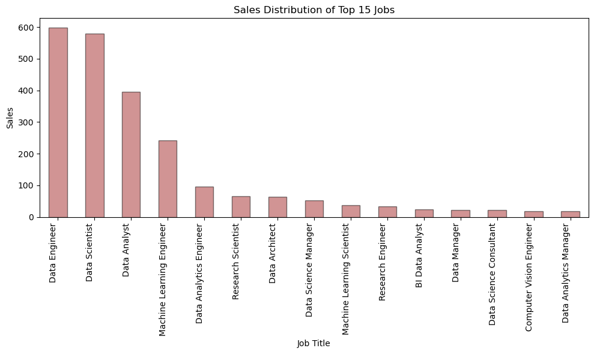

```python
# Creating a bar chart to visualize the frequency distribution of the top 15 job titles

# Setting the figure size
plt.figure(figsize=(10, 6))

# Plotting a bar chart of the top 15 job titles
top_jobs.plot(kind='bar', color="brown", alpha = 0.5, edgecolor='black')

# Setting the title of the chart
plt.title('Sales Distribution of Top 15 Jobs')

# Setting the label for the x-axis
plt.xlabel('Job Title')

# Setting the label for the y-axis
plt.ylabel('Sales')

# Rotating x-axis labels for better readability
plt.xticks(rotation=90, ha='right')

# Adjusting layout to prevent overlap of labels
plt.tight_layout()

# Displaying the chart
plt.show()
```

## Which job has the highest salaries? Illustrate with bar graph.

```python
# Calculate the mean (average) salary for each job title
mean_salary_by_job = df.groupby('job_title')['salary_in_usd'].mean()

# Find the job title with the highest mean salary
highest_salary_job_title = mean_salary_by_job.idxmax()

# Get the highest mean salary
highest_salary_job_amount = mean_salary_by_job.loc[highest_salary_job_title]

# Print the result
print(f"The job with the highest average salary is '{highest_salary_job_title}' with a mean salary of ${highest_salary_job_amount:.2f}.")
```

```
The job with the highest average salary is 'Data Science Tech Lead' with a mean salary of $375000.00.
```

### Visualizing the Top-Paying Jobs with a Bar Graph

## Which job has the highest salaries?(Bar Graph)

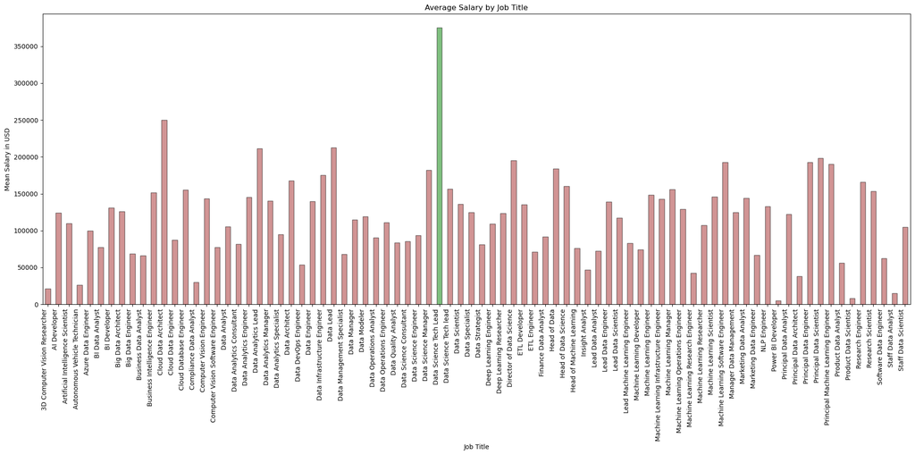

```python
# Calculating the mean salary for each job title
mean_salary_by_job = df.groupby('job_title')['salary_in_usd'].mean()

# Identifying the job title with the highest mean salary
highest_salary_job_title = mean_salary_by_job.idxmax()

# Setting the size of the figure
plt.figure(figsize=(20, 10))

# Defining colors for the bar graph, highlighting the highest paying job in purple
colors = ['green' if job == highest_salary_job_title else 'brown' for job in mean_salary_by_job.index]

# Creating the bar graph with appropriate colors
mean_salary_by_job.plot(kind='bar', color=colors, alpha=0.5, edgecolor='black')

# Adding a title to the chart
plt.title('Average Salary by Job Title')

# Labeling the x-axis
plt.xlabel('Job Title')

# Labeling the y-axis
plt.ylabel('Mean Salary in USD')

# Rotating the x-axis labels for better readability
plt.xticks(rotation=90, ha='right')

# Adjusting the layout to prevent overlapping of labels and titles
plt.tight_layout()

# Displaying the plot
plt.show()
```

## Write a python program to find out salaries based on experience level. Illustrate it through bar graph

### Finding out salaries based on experience level

```python
#counts the number of different experience_level present
ExprienceLevel= df.groupby('experience_level')['salary_in_usd'].mean()
print("-" * 45)
ExprienceLevel
```

```
experience_level
Entry Level                   72648.685185
Executive Level              191078.208333
Medium Level/Intermediate    101828.783133
Senior Level/Expert          153897.435650
Name: salary_in_usd, dtype: float64
```

```python
# Calculating the mean salary for each different experience level group
average_salary_by_experience = df.groupby('experience_level')['salary_in_usd'].mean()

# Sorting the data by average salary for each experience level
average_salary_by_experience = average_salary_by_experience.sort_values()

# Displaying the average salary based on experience level
print("\nAverage Salary by Experience Level:\n")
print("-" * 45)
print(average_salary_by_experience)
```

```
Average Salary by Experience Level:

---------------------------------------------
experience_level
Entry Level                   72648.685185
Medium Level/Intermediate    101828.783133
Senior Level/Expert          153897.435650
Executive Level              191078.208333
Name: salary_in_usd, dtype: float64
```

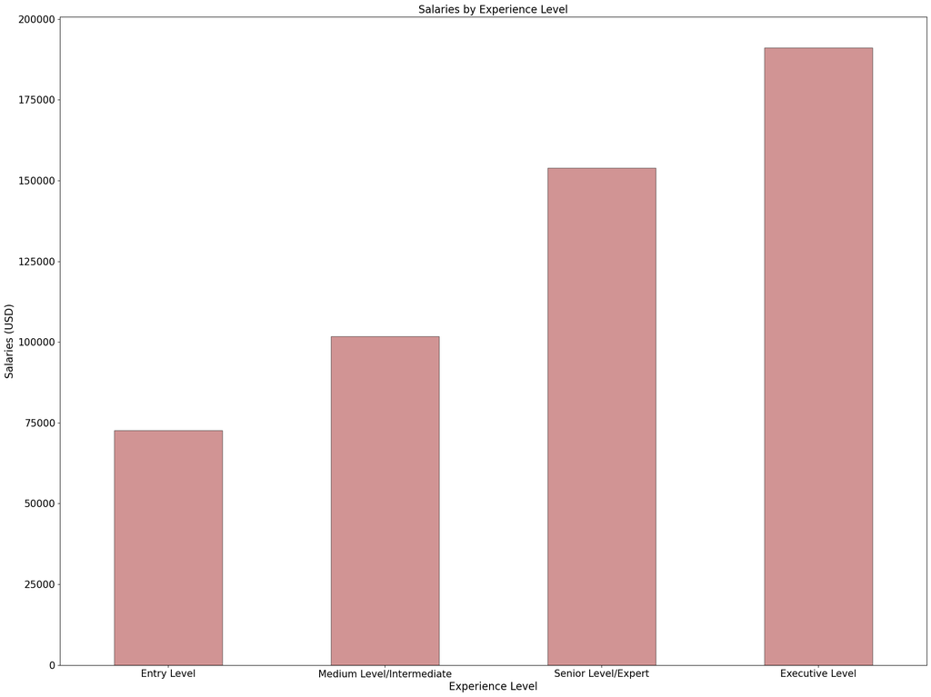

```python
# Creating a bar graph to visualize salaries based on experience level

plt.figure(figsize=(20, 15))  # Set the figure size

# Create a bar chart
average_salary_by_experience.plot(kind='bar', color='brown', alpha = 0.5, edgecolor='black')

plt.title('Salaries by Experience Level', fontsize=16)  # Set the title of the chart
plt.xlabel('Experience Level', fontsize=16)  # Set the label for the x-axis
plt.ylabel('Salaries (USD)', fontsize=16)  # Set the label for the y-axis

plt.xticks(rotation=360, fontsize=15)  # Rotate x-axis labels for better readability
plt.yticks(fontsize=15)  # Set font size for y-axis ticks

plt.tight_layout()  # Adjust layout to prevent overlap of labels
plt.show()  # Display the chart
```

## Write a Python program to show histogram and box plot of any chosen different variables. Use proper labels in the graph

#### Histogram of choosen variables -- salary_in_usd

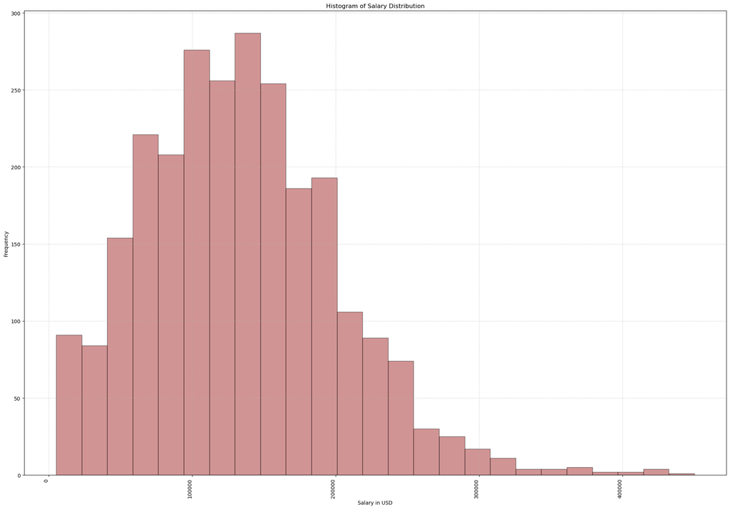

```python
# Visualizing the distribution of salaries using a histogram

# Setting the size of the figure
plt.figure(figsize=(20, 14))

# Creating the histogram with 20 bins, skyblue color, black edges, and 70% transparency
plt.hist(df['salary_in_usd'], bins=25, color='brown', edgecolor='black', alpha=0.5, linewidth=1)

# Adding gridlines to the plot
plt.grid(True, linestyle='--', alpha=0.5)

# Setting the title of the histogram
plt.title('Histogram of Salary Distribution')

# Labeling the x-axis with salary values in USD
plt.xlabel('Salary in USD')

# Labeling the y-axis with frequency of salaries
plt.ylabel('Frequency')

# Rotating the x-axis labels for better readability and alignment
plt.xticks(rotation=90, ha='right')

# Adding text annotation for mean salary
mean_salary = df['salary_in_usd'].mean()

# Adjusting the layout to prevent overlapping of labels and titles
plt.tight_layout()

# Displaying the histogram
plt.show()
```

#### Box plot of chosen variables--salary_in_usd

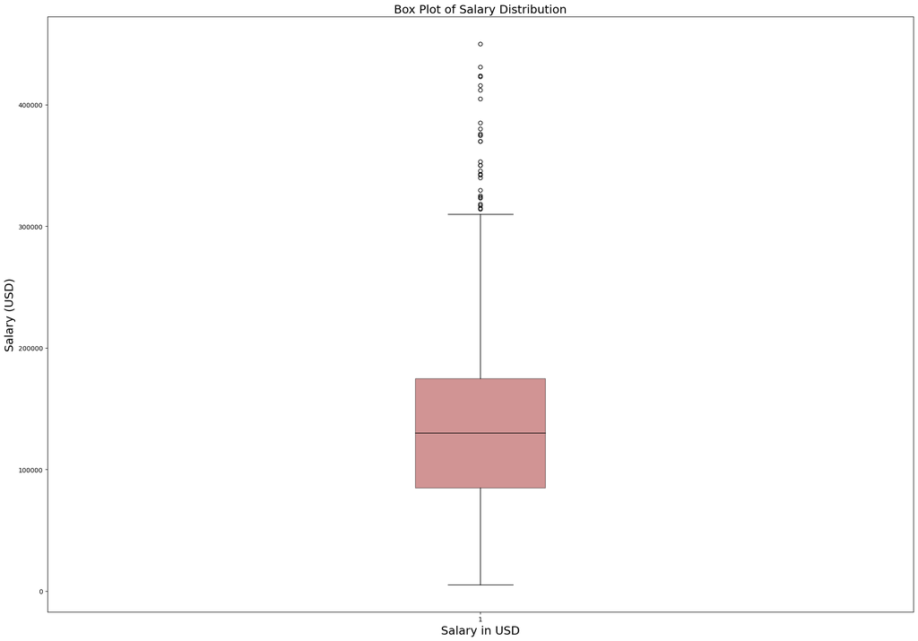

```python
# Illustrating the distribution of salaries using a box plot

# Setting the size of the figure
plt.figure(figsize=(20, 14))

# Plotting the box plot for salary distribution
plt.boxplot(df['salary_in_usd'], patch_artist=True, boxprops=dict(facecolor='brown',  alpha= 0.5, color='black'), medianprops=dict(color='black'))

# Setting the title of the chart
plt.title('Box Plot of Salary Distribution', fontsize=18)

# Setting the label for the x-axis
plt.xlabel('Salary in USD', fontsize=18)

# Setting the label for the y-axis
plt.ylabel('Salary (USD)', fontsize=18)

# Adjusting the layout to prevent overlapping of labels and titles
plt.tight_layout()

# Displaying the plot
plt.show()
```

#### Illustrating Histogram and Box plot together of chossen variable -- salary_in_usd

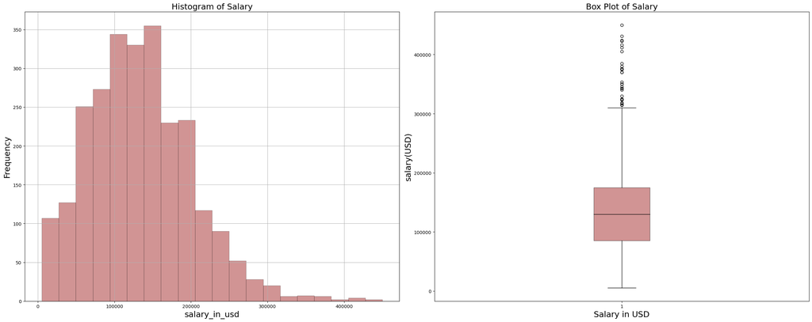

```python
#Plotting the box plot and histogram

#Set the figure size
plt.figure(figsize=(25, 10))

#Subplot 1: Histogram

#Create a subplot for Histogram
plt.subplot(1, 2, 1)


 #Creating a histogram for the 'salary_in_usd' column
df['salary_in_usd'].hist(bins=20, linewidth=0.5, color="brown", alpha=0.5, edgecolor = 'black')

# Setting the title of the chart
plt.title('Histogram of Salary', fontsize=18)

# Setting the label for the x-axis
plt.xlabel('salary_in_usd', fontsize=18)

# Setting the label for the y-axis
plt.ylabel('Frequency', fontsize=18)

#Subplot 2: Box Plot

#Create a subplot for boxplot
plt.subplot(1, 2, 2)

# Plotting the box plot with customized colors and styles
plt.boxplot(df['salary_in_usd'], patch_artist=True, boxprops=dict(facecolor='brown', alpha=0.5, color='black'), medianprops=dict(color='black'))


# #Creating a box plot for the 'salary_in_usd' column
# df.boxplot(column='salary_in_usd')

# Setting the title of the chart
plt.title('Box Plot of Salary', fontsize=18)

# Setting the label for the x-axis
plt.xlabel('Salary in USD', fontsize=18)

# Setting the label for the y-axis
plt.ylabel('salary(USD)', fontsize=18)

# Adjusting the layout to prevent overlapping of labels and titles
plt.tight_layout()

# Displaying the plot
plt.show()
```